# Shiny Examples

Joshua Kunst

2022-08-08

Source: [`vignettes/shiny.Rmd`](https://github.com/jbkunst/highcharter/blob/HEAD/vignettes/shiny.Rmd)

Let’s check some examples!

## Hello Word with highcharter

- Live: http://jbkunst.shinyapps.io/01-get-started
- Code: https://github.com/jbkunst/highcharter-shiny/tree/master/01-get-started

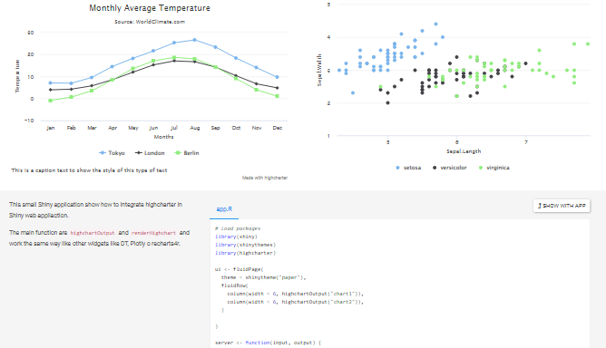

This small Shiny application show how to integrate highcharter in Shiny web appliaction.

The main function are `highchartOutput` and `renderHighchart` and work the same way like other widgets like DT, Plotly o recharts4r.

## Proxy functions

- Live: http://jbkunst.shinyapps.io/02-proxy-functions
- Code: https://github.com/jbkunst/highcharter-shiny/tree/master/02-proxy-functions

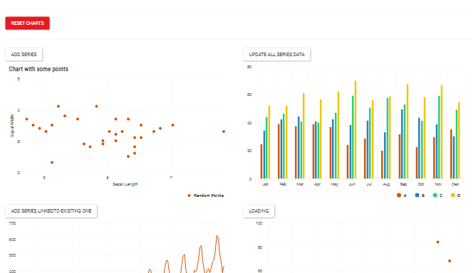

Proxy functions allow you modify the highcharter widget without redraw the entire chart.

The functions implemented are:

- `hcpxy_add_series` To add a new series to an existing highcharter widget.
- `hcpxy_remove_series` Remove specific series of a highcharter widget.
- `hcpxy_update` Change general chart options of a widget.
- `hcpxy_update_series` Change series options of a widget.
- `hcpxy_add_point` To add a specific point from a specific series.
- `hcpxy_remove_point` To remove a specific point from a specific series.
- `hcpxy_loading` To enable or disable the the loading icon over the widget.

To use this function you need a widget in your `ui`, let’s say:

```r
ui <- fluidPage(
  ...,
  highchartOutput("widget"),
  ...
  )
```

If you need to modify the widget associated to `highchartOutput("widget")` you need to create a proxy object indicating the id, in this case `"widget"`. It’s important to use the argument `session` to define the server.

```r
server <- function(input, output, session){

  # some where in you server, probably in a observeEvent

  observeEvent(input$idbutton, {

    highchartProxy("widget") %>%
      # modify options
      hcpxy_update(
        title = list(text = "A new title"),
        chart = list(inverted = FALSE, polar = FALSE),
        xAxis = list(gridLineWidth =  1),
        yAxis = list(endOnTick = FALSE),
        chart = list(inverted = FALSE, polar = TRUE)
      ) %>%
      # add data
      hc_add_series(df, "line", hcaes(x, y), id = "ts", name = "A real time value")
  })

}
```

Don’t forget to check the code example.

## Shiny Events Demo

- Live: http://jbkunst.shinyapps.io/03-events-v2
- Code: https://github.com/jbkunst/highcharter-shiny/tree/master/03-events-v2

Using `hc_add_event_point` and `hc_add_event_series` it is possible extract click and mouse over events from a Highchart within a Shiny app. To extract this information from the chart, `input$` variables are created as follows:

```
paste0("highchart_output", "_", "eventType")
```

- `input$plot_hc_click`
- `input$plot_hc_mouseOver`

## Events functions helpers

- Live: http://jbkunst.shinyapps.io/03-events
- Code: https://github.com/jbkunst/highcharter-shiny/tree/master/03-events

[figure not shown]

Highcharter have some helpers function to know what point is selected by the user.

For example, let’s say you have some app with a `renderHighcharter("chart")` in the ui. To know what point is selected you need to use `hc_add_event_point` and specify the event `"click"` or `"mouseOver"`. Then is possible check the value using `input$chart_click` or `input$chart_mouseOver` depending the type of event selected in `hc_add_event_point`.

## Highcharter widgets in valueBoxes

- Live: http://jbkunst.shinyapps.io/04-shinydashboard-n-spakrlines
- Code: https://github.com/jbkunst/highcharter-shiny/tree/master/04-shinydashboard-n-spakrlines

[figure not shown]

This is an example showing how highcharter widgets can be put inside in a valueBoxes from the packages shinydashboard or bs4dash. You can see more details in https://jkunst.com/blog/posts/2020-06-26-valuebox-and-sparklines/.

## ARMA model simulation

- Live: http://jbkunst.shinyapps.io/05-arma
- Code: https://github.com/jbkunst/highcharter-shiny/tree/master/05-arma

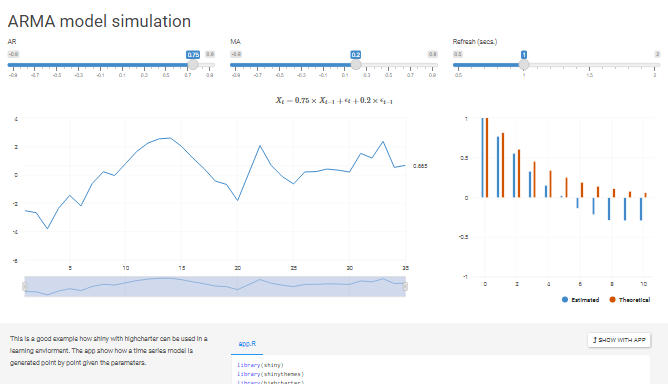

This is a good example how shiny with highcharter can be used in a learning enviorment. The app show how a time series model is generated point by point given the parameters.

## Improving a map performance

- Live: http://jbkunst.shinyapps.io/06-maps-performance
- Code: https://github.com/jbkunst/highcharter-shiny/tree/master/06-maps-performance

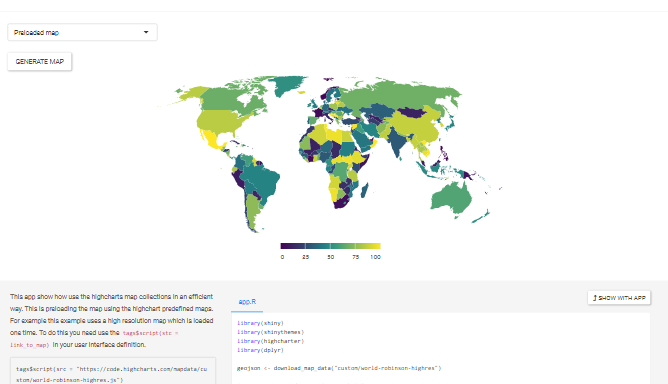

This app show how use the highcharts map collections in an efficient way. This is preloading the map using the highchart predefined maps. For example this example uses a high resolution map which is loaded one time. To do this you need use the `tags$script(stc = link_to_map)` in your user interface definition.

```r
tags$script(src = "https://code.highcharts.com/mapdata/custom/world-robinson-highres.js")
```

Then, in your server:

```r
mapdata <- JS("Highcharts.maps['custom/world-robinson-highres']")

highchart(type = "map") %>%
  hc_add_series(mapData = mapdata, data = data, joinBy = c("hc-key"))
```

You can see other predefined maps in https://code.highcharts.com/mapdata/.

## NYTimes temperature app

- Live: http://jbkunst.shinyapps.io/07-nyt-temp
- Code: https://github.com/jbkunst/highcharter-shiny/tree/master/07-nyt-temp

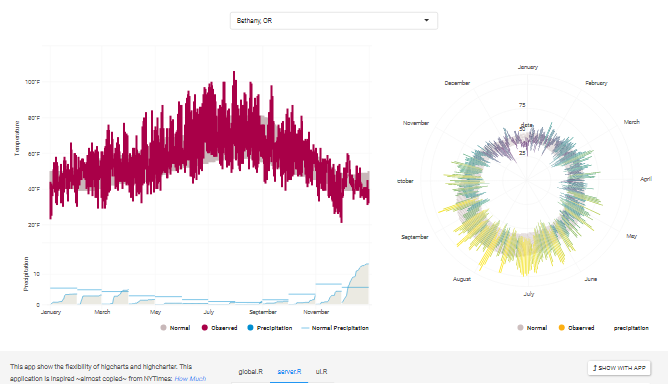

This app show the flexibility of higcharts and highcharter. This application is inspired ~almost copied~ from NYTimes: [*How Much Warmer Was Your City in 2015?*](http://www.nytimes.com/interactive/2016/02/19/us/2015-year-in-weather-temperature-precipitation.html). For weather radials, inspiration comes from [weather-radials.com](http://www.weather-radials.com/).

## 08-idb-viz

- Live: http://jbkunst.shinyapps.io/08-idb-viz
- Code: https://github.com/jbkunst/highcharter-shiny/tree/master/08-idb-viz

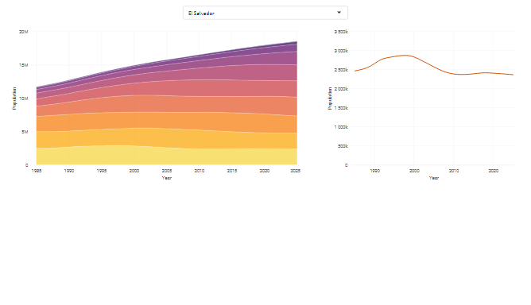

## Piramid Census

- Live: http://jbkunst.shinyapps.io/09-piramid-census
- Code: https://github.com/jbkunst/highcharter-shiny/tree/master/09-piramid-census

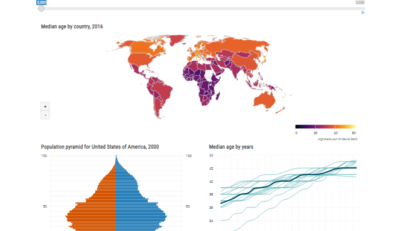

This apps show how you can use the highcharter widgets like inputs elements. For example, clicking in a point, line, country triggers an event, a change in an input. The app uses idbr package by [Kyle Walke](http://walkerke.github.io/).

The key parts to get this feature are:

1. Define a Javascript function to use the `Shiny.onInputChange`, the parameter for this functions are the name of te input to listen in the server and the value of this input. In this example the name of the input is `hcworldinput` and `this.name`. This last argument is a special value in highcharter to get the name of the series or point.
2. Use the previous function in a highcharter widget in the event that it’s required, for example, hover, click, etc.
3. Then use `input$hcworldinput` in the server side of the app.

```
fn <- "function(){
    console.log(this.name);
    Shiny.onInputChange('hcworldinput', this.name)
  }"

hc %>%
  hc_plotOptions(
    series = list(
      cursor = "pointer",
      point = list(
        events = list(click = JS(fn)
        )
      )
    )
  )
```